# US Agricultural Tariffs: A Comprehensive Analysis

- Show All Code
- Hide All Code
- View Source

USITC Tariff Database · HTS Chapters 1–24 · TidyTuesday 2026 Week 17

Author

Erick K Yegon, PhD

Published

May 14, 2026

Abstract

Keywords

TidyTuesday, tariffs, trade policy, USITC, agricultural trade, NAFTA, USMCA, HTS, R, data-visualisation

**Show / hide code**

```r
pkgs <- c(
  "tidyverse", "lubridate", "scales", "ggtext", "ggrepel",
  "patchwork", "gt", "gtExtras", "glue", "ggridges",
  "RColorBrewer", "forcats", "stringr", "janitor", "knitr",
  "kableExtra", "DT", "plotly", "crosstalk",
  "broom", "Kendall", "dunn.test"
)
installed  <- rownames(installed.packages())
to_install <- pkgs[!pkgs %in% installed]
if (length(to_install)) install.packages(to_install, quiet = TRUE)

suppressPackageStartupMessages({
  library(tidyverse); library(lubridate); library(scales)
  library(ggtext);    library(ggrepel);   library(patchwork)
  library(gt);        library(gtExtras);  library(glue)
  library(ggridges);  library(RColorBrewer); library(forcats)
  library(stringr);   library(janitor);   library(knitr)
  library(kableExtra);library(DT);        library(plotly)
  library(crosstalk); library(broom);     library(Kendall)
  library(dunn.test)
})
```

**Show / hide code**

```r
theme_tariff <- function(base_size = 12) {
  theme_minimal(base_size = base_size) +
    theme(
      text              = element_text(colour = "#2C2C2A"),
      plot.title        = element_markdown(size = rel(1.35), face = "bold",
                                           margin = margin(b = 6)),
      plot.subtitle     = element_markdown(size = rel(0.95), colour = "#5F5E5A",
                                           lineheight = 1.4, margin = margin(b = 12)),
      plot.caption      = element_markdown(size = rel(0.72), colour = "#888780",
                                           hjust = 0, margin = margin(t = 10)),
      plot.background   = element_rect(fill = "#FAFAF8", colour = NA),
      panel.background  = element_rect(fill = "#FAFAF8", colour = NA),
      panel.grid.major  = element_line(colour = "#D3D1C7", linewidth = 0.35),
      panel.grid.minor  = element_blank(),
      axis.title        = element_text(size = rel(0.85), colour = "#5F5E5A"),
      axis.text         = element_text(size = rel(0.80), colour = "#5F5E5A"),
      axis.ticks        = element_blank(),
      strip.text        = element_markdown(size = rel(0.85), face = "bold",
                                           colour = "#3C3489"),
      strip.background  = element_rect(fill = "#EEEDFE", colour = NA),
      legend.position   = "bottom",
      legend.title      = element_text(size = rel(0.82), colour = "#5F5E5A"),
      legend.text       = element_text(size = rel(0.78)),
      plot.margin       = margin(14, 14, 10, 14)
    )
}
theme_set(theme_tariff())

# Colour-blind-safe palette (Wong 2011)
pal_section <- c(
  "Live Animals & Animal Products" = "#D55E00",
  "Vegetable Products"             = "#009E73",
  "Animal/Vegetable Fats & Oils"   = "#CC79A7",
  "Prepared Foodstuffs"            = "#0072B2"
)

pal_agree <- c(
  "MFN"         = "#534AB7",
  "NAFTA/USMCA" = "#1D9E75",
  "Bilateral"   = "#D85A30",
  "Other GSP"   = "#BA7517"
)
```

## 1 Introduction

#TidyTuesday · Week 17 · 2026-04-28

**NoteAbout this dataset**

Four datasets are provided and **all four are used** in this analysis:

| Dataset | Role in this analysis |
| --- | --- |
| `tariff_agricultural` | Main data: one row per HTS-8 × agreement × date period |
| `agreements` | Lookup: agreement codes → full names, notes, eligibility |
| `tariff_codes` | Lookup: HTS-8 → product descriptions, quantity units, WTO binding |
| `quantity_codes` | Reference: unit codes (KG, NO, M2) → descriptions |

> ⚠️ **Important:** All patterns described below are **descriptive and correlational only**. There are many moderating variables — trade volumes, commodity market cycles, WTO binding commitments, exchange rates — not captured in this dataset. **No causal claims are made.**

**Research questions (exploratory / descriptive):**

1. How have MFN tariff rates trended across the four agricultural HTS sections?
2. What rate differences exist between NAFTA/USMCA and MFN agreements?
3. Which specific tariff lines show the most rate variability over time?
4. Did the NAFTA → USMCA transition (2020) coincide with visible rate changes?
5. Is there an association between MFN rate levels and preferential agreement coverage?
6. Do rate distributions differ significantly across sections (nonparametric tests)?
7. Is there a detectable monotonic trend in MFN rates over time?

📣 **Share this work:** Post with **#TidyTuesday** · Code on [GitHub](https://github.com/rfordatascience/tidytuesday/blob/main/sharing.md) · Dataset: [2026-04-28](https://github.com/rfordatascience/tidytuesday/blob/main/data/2026/2026-04-28/readme.md)

## 2 Data Ingestion & Validation

**Show / hide code**

```r
base_url <- paste0(
  "https://raw.githubusercontent.com/rfordatascience/tidytuesday/",
  "main/data/2026/2026-04-28/"
)

safe_read <- function(file) {
  readr::read_csv(paste0(base_url, file),
                  show_col_types = FALSE, progress = FALSE)
}

agreements          <- safe_read("agreements.csv")
quantity_codes      <- safe_read("quantity_codes.csv")
tariff_agricultural <- safe_read("tariff_agricultural.csv")
tariff_codes        <- safe_read("tariff_codes.csv")
```

**Show / hide code**

```r
tibble(
  Dataset      = c("tariff_agricultural","agreements","quantity_codes","tariff_codes"),
  Rows         = c(nrow(tariff_agricultural), nrow(agreements),
                   nrow(quantity_codes),      nrow(tariff_codes)),
  Columns      = c(ncol(tariff_agricultural), ncol(agreements),
                   ncol(quantity_codes),      ncol(tariff_codes)),
  `Key join`   = c("hts8 + agreement + dates", "agreement",
                   "code", "hts8")
) |>
  gt() |>
  fmt_integer(columns = c(Rows, Columns)) |>
  tab_style(style = cell_text(weight = "bold"),
            locations = cells_column_labels()) |>
  tab_options(table.font.size = px(13))
```

Table 1: All four TidyTuesday datasets — dimensions after ingestion

| Dataset | Rows | Columns | Key join |
| --- | --- | --- | --- |
| tariff_agricultural | 461,738 | 7 | hts8 + agreement + dates |
| agreements | 34 | 3 | agreement |
| quantity_codes | 82 | 2 | code |
| tariff_codes | 27,360 | 6 | hts8 |

461,738Tariff records

2,686HTS-8 codes

26Agreement codes

1989–2100Year span

82Quantity units

**Quick facts**

HTS-8 codes: 2686

Agreement codes: 26

Years: 1989–2100

`ad_val_rate`: **decimal** (0.05 = 5%)

### 2.1 Data dictionary

**Warning`ad_val_rate` is stored as a decimal**

Per the official data dictionary: `ad_val_rate` of `0.05` means **5%**, not 0.05%. This is multiplied by 100 in all cleaning steps. `specific_rate` is in **US dollars per unit of quantity** (e.g., `0.05` = $0.05/kg).

**Show / hide code**

```r
tribble(
  ~Variable,              ~Type,       ~Description,
  "hts8",                 "character", "8-digit HTS code — join with tariff_codes for descriptions",
  "begin_effective_date", "date",      "Start date for this rate period (rates can change mid-year)",
  "end_effective_date",   "date",      "End date — far-future dates (e.g. 2050-12-31) = no scheduled change",
  "agreement",            "character", "Agreement code — join with agreements for full name and notes",
  "rate_type_code",       "character", "Duty method (0=free, 7=ad valorem; see USITC td-codes.pdf)",
  "ad_val_rate",          "double",    "Ad valorem rate as DECIMAL — 0.05 = 5%",
  "specific_rate",        "double",    "Per-unit rate in USD — 0.05 = $0.05 per unit of quantity"
) |>
  gt() |>
  tab_header(title = md("**`tariff_agricultural` data dictionary**")) |>
  tab_style(style = cell_text(weight = "bold"),
            locations = cells_column_labels()) |>
  tab_style(style = cell_fill(color = "#FAEEDA"),
            locations = cells_body(rows = Variable == "ad_val_rate")) |>
  tab_style(style = cell_fill(color = "#FAEEDA"),
            locations = cells_body(rows = Variable == "specific_rate")) |>
  tab_options(table.font.size = px(12))
```

Table 2: Key variables in tariff_agricultural.csv (official data dictionary)

**`tariff_agricultural` data dictionary**

| Variable | Type | Description |
| --- | --- | --- |
| hts8 | character | 8-digit HTS code — join with tariff_codes for descriptions |
| begin_effective_date | date | Start date for this rate period (rates can change mid-year) |
| end_effective_date | date | End date — far-future dates (e.g. 2050-12-31) = no scheduled change |
| agreement | character | Agreement code — join with agreements for full name and notes |
| rate_type_code | character | Duty method (0=free, 7=ad valorem; see USITC td-codes.pdf) |
| ad_val_rate | double | Ad valorem rate as DECIMAL — 0.05 = 5% |
| specific_rate | double | Per-unit rate in USD — 0.05 = $0.05 per unit of quantity |

### 2.2 Agreements reference

**Show / hide code**

```r
agreements |>
  arrange(agreement) |>
  gt() |>
  tab_header(
    title    = md("**`agreements.csv` — all trade agreement codes**"),
    subtitle = md("*Asterisk/plus suffixes = restrictions or enhanced benefits*")
  ) |>
  cols_label(
    agreement       = "Code",
    agreement_full  = "Full name",
    agreement_notes = "Notes"
  ) |>
  tab_style(style = cell_text(weight = "bold"),
            locations = cells_column_labels()) |>
  tab_style(style = cell_fill(color = "#EEEDFE"),
            locations = cells_body(rows = str_detect(agreement, "mfn"))) |>
  tab_style(style = cell_fill(color = "#EAF3DE"),
            locations = cells_body(rows = str_detect(agreement, "canada|mexico|usmca"))) |>
  sub_missing(missing_text = "—") |>
  tab_options(table.font.size = px(11))
```

Table 3: Full agreements lookup table — used to classify agree_group in cleaning

**`agreements.csv` — all trade agreement codes**

*Asterisk/plus suffixes = restrictions or enhanced benefits*

| Code | Full name | Notes |
| --- | --- | --- |
| agoa | African Growth and Opportunity Act (AGOA) | — |
| apta | Automotive Products Trade Act (APTA) | Duty-free |
| atpa | Andean Trade Preference Act (ATPA) | Program expired |
| atpa* | Andean Trade Preference Act (ATPA) | Certain products excluded; program expired |
| atpdea | Andean Trade Promotion and Drug Eradication Act (ATPDEA) | Program expired |
| australia | Australia-United States Free Trade Agreement | — |
| bahrain | Bahrain-United States Free Trade Agreement | — |
| canada | North American Free Trade Agreement (NAFTA) | Canada |
| cbi | Caribbean Basin Initiative (CBI) | — |
| cbi* | Caribbean Basin Initiative (CBI) | Certain products or countries excluded |
| cbtpa | Caribbean Basin Trade Partnership Act (CBTPA) | — |
| chile | Chile-United States Free Trade Agreement | — |
| civil_air | Agreement on Trade in Civil Aircraft | Duty-free |
| col2 | Column 2 Rates | Non-market economy countries |
| colombia | Colombia-United States Trade Promotion Agreement | — |
| dr_cafta | Dominican Republic-Central America Free Trade Agreement (DR-CAFTA) | — |
| dr_cafta_plus | Dominican Republic-Central America Free Trade Agreement (DR-CAFTA) | Plus rate |
| dyes | Uruguay Round Concessions on Intermediate Chemicals for Dyes | Duty-free |
| gsp | Generalized System of Preferences (GSP) | Duty-free for eligible beneficiary countries |
| israel_fta | Israel-United States Free Trade Agreement | Duty-free |
| japan | United States-Japan Trade Agreement | — |
| jordan | Jordan-United States Free Trade Agreement | — |
| korea | Korea-United States Free Trade Agreement (KORUS) | — |
| mexico | North American Free Trade Agreement (NAFTA) | Mexico |
| mfn | Most Favored Nation (MFN) | Standard rates for WTO members |
| morocco | Morocco-United States Free Trade Agreement | — |
| nepal | Nepal Trade Preference Program | — |
| oman | Oman-United States Free Trade Agreement | — |
| panama | Panama-United States Trade Promotion Agreement | — |
| peru | Peru-United States Trade Promotion Agreement | — |
| pharmaceutical | Agreement on Trade in Pharmaceutical Products | Duty-free |
| singapore | Singapore-United States Free Trade Agreement | — |
| usmca | United States-Mexico-Canada Agreement (USMCA) | — |
| usmca+ | United States-Mexico-Canada Agreement (USMCA) | Plus rate |

### 2.3 Quantity units in use

**Show / hide code**

```r
used_qty <- tariff_codes |>
  janitor::clean_names() |>
  select(quantity_1_code, quantity_2_code) |>
  pivot_longer(everything(), values_to = "code") |>
  filter(!is.na(code)) |>
  distinct(code)

quantity_codes |>
  semi_join(used_qty, by = "code") |>
  arrange(code) |>
  gt() |>
  tab_header(
    title    = md("**Quantity units from `quantity_codes.csv`**"),
    subtitle = md("*Filtered to codes used in HTS Ch. 1–24 tariff lines*")
  ) |>
  cols_label(code = "Unit code", description = "Description") |>
  tab_style(style = cell_text(weight = "bold"),
            locations = cells_column_labels()) |>
  tab_options(table.font.size = px(12))
```

Table 4: Quantity unit codes appearing in agricultural tariff lines (quantity_codes joined via tariff_codes)

**Quantity units from `quantity_codes.csv`**

*Filtered to codes used in HTS Ch. 1–24 tariff lines*

| Unit code | Description |
| --- | --- |
| BBL | barrels |
| CAR | carats |
| CGM | component grams |
| CKG | component kilograms |
| CM2 | square centimeters |
| CTN | component tons |
| CYK | clean yield kilograms |
| DOZ | dozens |
| DPC | dozen pieces |
| DPR | dozen pairs |
| DS | doses |
| FBM | fiber meters |
| G | grams |
| GCN | gross containers |
| GM | grams |
| GR | gross |
| GRL | gross lines |
| GRS | gross |
| HUN | hundred units |
| JWL | jewels |
| K | thousand units |
| KG | kilograms |
| KM | kilometers |
| KM3 | kilograms per cubic meter |
| KTS | kilograms total sugars |
| KWH | kilowatts-hours |
| L | liters |
| LNM | linear meters |
| M | meters |
| M2 | square meters |
| M3 | cubic meters |
| NO | number |
| ODE | ozone depletion equivalent |
| PCS | pieces |
| PFL | proof liters |
| PK | pack |
| PRS | pairs |
| SME | square meters equivalent |
| SQ | squares |
| T | metric tons |
| THS | thousand units |
| W | watts |
| X | no quantity data collected |

## 3 Data Cleaning & Feature Engineering

**Show / hide code**

```r
# ── 1. tariff_codes lookup: hts8 → description, qty units, WTO ──
tc_lookup <- tariff_codes |>
  janitor::clean_names() |>
  arrange(hts8, desc(earliest_effective_date)) |>
  distinct(hts8, .keep_all = TRUE) |>
  select(hts8, product_desc = description,
         qty1 = quantity_1_code, qty2 = quantity_2_code,
         wto  = wto_binding_code)

# ── 2. agreements classification (uses agreement column directly) ─
agree_classified <- agreements |>
  janitor::clean_names() |>
  mutate(
    agree_group = case_when(
      str_detect(agreement, "^mfn$")                                     ~ "MFN",
      str_detect(agreement, "canada|mexico|usmca")                       ~ "NAFTA/USMCA",
      str_detect(agreement,
                 "australia|chile|korea|colombia|peru|singapore|
                  bahrain|morocco|oman|panama|jordan|japan|israel_fta")   ~ "Bilateral",
      agreement == "col2"                                                ~ "Column 2",
      TRUE                                                               ~ "Other GSP"
    ),
    agree_group = factor(agree_group,
                         levels = c("MFN","NAFTA/USMCA","Bilateral","Other GSP","Column 2"))
  )

# ── 3. Clean tariff_agricultural ────────────────────────────────
# CRITICAL: ad_val_rate is decimal → multiply by 100 for percentage
tariff_clean <- tariff_agricultural |>
  janitor::clean_names() |>
  mutate(
    begin_date  = as.Date(begin_effective_date),
    end_date    = as.Date(end_effective_date),
    begin_year  = year(begin_date),
    end_year    = year(end_date),
    ad_val_pct  = ad_val_rate * 100,            # 0.05 → 5%
    hts_chapter = as.integer(str_sub(as.character(hts8), 1, 2)),
    section = case_when(
      hts_chapter <= 5  ~ "Live Animals & Animal Products",
      hts_chapter <= 14 ~ "Vegetable Products",
      hts_chapter <= 15 ~ "Animal/Vegetable Fats & Oils",
      hts_chapter <= 24 ~ "Prepared Foodstuffs",
      TRUE              ~ "Other"
    ),
    section = factor(section, levels = names(pal_section))
  ) |>
  left_join(tc_lookup,        by = "hts8") |>
  left_join(agree_classified, by = "agreement")

# ── 4. Annual panel (HTS8 × agreement × year 2000–2024) ─────────
YEARS <- 2000:2024

annual_panel <- tariff_clean |>
  distinct(hts8, agreement) |>
  crossing(year = YEARS) |>
  left_join(
    tariff_clean |>
      select(hts8, agreement, begin_year, end_year,
             ad_val_pct, specific_rate, hts_chapter, section,
             agree_group, agreement_full, agreement_notes,
             product_desc, qty1, qty2, wto),
    join_by(hts8, agreement, year >= begin_year, year <= end_year)
  ) |>
  filter(!is.na(ad_val_pct), ad_val_pct >= 0, ad_val_pct < 500) |>
  distinct(hts8, agreement, year, .keep_all = TRUE) |>
  filter(agree_group != "Column 2")   # exclude non-market economy rates

# ── 5. MFN-only subset ───────────────────────────────────────────
mfn_panel <- annual_panel |>
  filter(agree_group == "MFN") |>
  select(hts8, year, section, hts_chapter, mfn_rate = ad_val_pct,
         product_desc, qty1, wto)

cat("Annual panel rows:", scales::comma(nrow(annual_panel)), "\n")
```

```
#> Annual panel rows: 450,163
```

**Show / hide code**

```r
cat("MFN panel rows   :", scales::comma(nrow(mfn_panel)), "\n")
```

```
#> MFN panel rows   : 54,666
```

**Show / hide code**

```r
cat("Distinct products:", scales::comma(n_distinct(mfn_panel$hts8)), "\n")
```

```
#> Distinct products: 2,659
```

**Show / hide code**

```r
cat("MFN rate range   :", round(min(mfn_panel$mfn_rate), 2), "% –",
    round(max(mfn_panel$mfn_rate), 2), "%\n")
```

```
#> MFN rate range   : 0 % – 350 %
```

**TipPipeline design**

- **Inequality join** (`join_by(year >= begin_year, year <= end_year)`) assigns the rate legally in force for each HTS × agreement × year — no rate-smearing across policy change dates.
- All four datasets joined: `tariff_agricultural` (base) + `agreements` (classification) + `tariff_codes` (descriptions) + `quantity_codes` (unit reference above).
- `ad_val_rate × 100` is the only non-obvious transformation required by the data dictionary.

## 4 Exploratory Data Analysis

**Reminder:** All patterns below are **descriptive only.** Observed associations do not imply causation. Many variables not in this dataset affect tariff levels and trade flows.

### 4.1 Section-level statistics

**Show / hide code**

```r
mfn_panel |>
  group_by(section) |>
  summarise(
    `Tariff lines` = n_distinct(hts8),
    `Obs. (n)`     = n(),
    `Mean rate`    = mean(mfn_rate, na.rm = TRUE),
    `Median`       = median(mfn_rate, na.rm = TRUE),
    `SD`           = sd(mfn_rate, na.rm = TRUE),
    `Min`          = min(mfn_rate, na.rm = TRUE),
    `Max`          = max(mfn_rate, na.rm = TRUE),
    `% zero-rated` = mean(mfn_rate == 0, na.rm = TRUE) * 100,
    `% WTO-bound`  = mean(wto == "B", na.rm = TRUE) * 100,
    .groups = "drop"
  ) |>
  gt() |>
  tab_header(
    title    = md("**MFN Rate Statistics by HTS Section**"),
    subtitle = md("*Ad valorem %. WTO bound (B) status from `tariff_codes.wto_binding_code`.*")
  ) |>
  cols_label(section = "Section") |>
  fmt_number(columns = c(`Mean rate`, Median, SD, Min, Max),
             decimals = 2, suffix = "%") |>
  fmt_number(columns = c(`% zero-rated`, `% WTO-bound`),
             decimals = 1, suffix = "%") |>
  fmt_integer(columns = c(`Tariff lines`, `Obs. (n)`)) |>
  data_color(columns = `Mean rate`,    palette = c("#E6F1FB","#185FA5")) |>
  data_color(columns = `% zero-rated`, palette = c("#185FA5","#E6F1FB")) |>
  data_color(columns = `% WTO-bound`,  palette = c("#E6F1FB","#009E73")) |>
  tab_style(style = cell_text(weight = "bold"),
            locations = cells_column_labels()) |>
  tab_options(table.font.size = px(13),
              column_labels.border.top.color = "#534AB7",
              column_labels.border.top.width = px(2))
```

Table 5: MFN rate summary statistics by HTS section (2000–2024). WTO bound status from tariff_codes.

**MFN Rate Statistics by HTS Section**

*Ad valorem %. WTO bound (B) status from `tariff_codes.wto_binding_code`.*

| Section | Tariff lines | Obs. (n) | Mean rate | Median | SD | Min | Max | % zero-rated | % WTO-bound |
| --- | --- | --- | --- | --- | --- | --- | --- | --- | --- |
| Live Animals & Animal Products | 883 | 17,064 | 3.24 | 0.00 | 5.88 | 0.00 | 26.40 | 68.2 | 100.0 |
| Vegetable Products | 764 | 15,827 | 2.99 | 0.00 | 10.72 | 0.00 | 163.80 | 70.4 | 99.8 |
| Animal/Vegetable Fats & Oils | 98 | 1,979 | 2.02 | 0.00 | 4.01 | 0.00 | 19.10 | 66.6 | 100.0 |
| Prepared Foodstuffs | 914 | 19,796 | 8.08 | 2.40 | 34.47 | 0.00 | 350.00 | 45.3 | 100.0 |

### 4.2 Agreement group coverage

**Show / hide code**

```r
annual_panel |>
  group_by(agree_group) |>
  summarise(
    `Distinct products` = n_distinct(hts8),
    `Product-years`     = n(),
    `Mean rate`         = mean(ad_val_pct, na.rm = TRUE),
    `Median rate`       = median(ad_val_pct, na.rm = TRUE),
    `Expired/restricted` = sum(!is.na(agreement_notes) &
                               str_detect(agreement_notes,
                                          "expired|excluded"), na.rm = TRUE),
    .groups = "drop"
  ) |>
  gt() |>
  cols_label(agree_group = "Agreement group") |>
  fmt_number(columns = c(`Mean rate`, `Median rate`), decimals = 2, suffix = "%") |>
  fmt_integer(columns = c(`Distinct products`, `Product-years`, `Expired/restricted`)) |>
  data_color(columns = `Mean rate`, palette = c("#E6F1FB","#185FA5")) |>
  tab_footnote(
    footnote  = "Rows where agreement_notes contains 'expired' or 'excluded' (from agreements.csv)",
    locations = cells_column_labels(columns = `Expired/restricted`)
  ) |>
  tab_style(style = cell_text(weight = "bold"),
            locations = cells_column_labels()) |>
  tab_options(table.font.size = px(13))
```

Table 6: Coverage and average rates by agreement group — using agreement_notes to flag expired programs

| Agreement group | Distinct products | Product-years | Mean rate | Median rate | Expired/restricted<sup>1</sup> |
| --- | --- | --- | --- | --- | --- |
| MFN | 2,659 | 54,666 | 4.88 | 0.00 | 0 |
| NAFTA/USMCA | 1,825 | 40,766 | 0.02 | 0.00 | 0 |
| Bilateral | 1,844 | 240,065 | 0.70 | 0.00 | 0 |
| Other GSP | 1,741 | 114,666 | 0.35 | 0.00 | 29,414 |

<sup>1</sup> Rows where agreement_notes contains 'expired' or 'excluded' (from agreements.csv)

**Show / hide code**

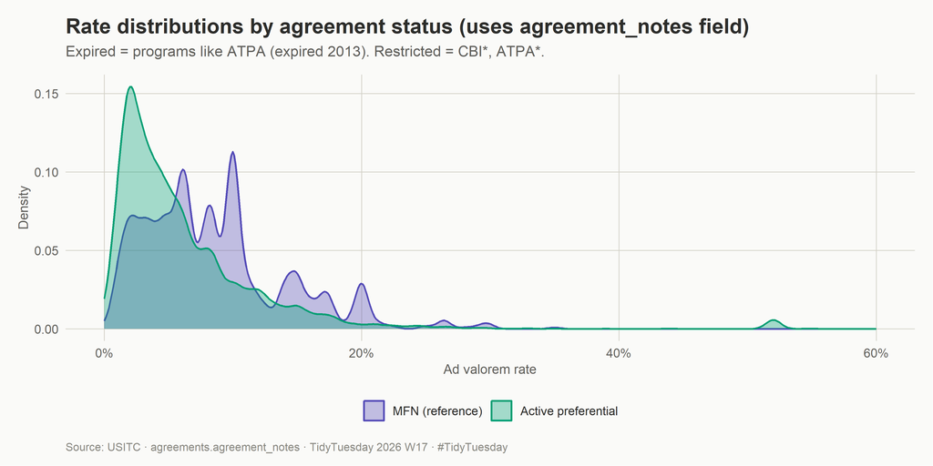

```r
annual_panel |>
  mutate(
    status = case_when(
      str_detect(coalesce(agreement_notes,""), "expired")  ~ "Expired program",
      str_detect(coalesce(agreement_notes,""), "excluded") ~ "Restricted",
      agree_group == "MFN"                                 ~ "MFN (reference)",
      TRUE                                                 ~ "Active preferential"
    ),
    status = factor(status, levels = c("MFN (reference)","Active preferential",
                                       "Restricted","Expired program"))
  ) |>
  filter(ad_val_pct > 0, ad_val_pct < 100) |>
  ggplot(aes(x = ad_val_pct, fill = status, colour = status)) +
  geom_density(alpha = 0.35, linewidth = 0.7) +
  scale_fill_manual(
    values = c("MFN (reference)"     = "#534AB7",
               "Active preferential" = "#009E73",
               "Restricted"          = "#BA7517",
               "Expired program"     = "#D55E00"), name = NULL) +
  scale_colour_manual(
    values = c("MFN (reference)"     = "#534AB7",
               "Active preferential" = "#009E73",
               "Restricted"          = "#BA7517",
               "Expired program"     = "#D55E00"), name = NULL) +
  scale_x_continuous(labels = label_number(suffix = "%"), limits = c(0, 60)) +
  labs(
    title    = "Rate distributions by agreement status (uses agreement_notes field)",
    subtitle = "Expired = programs like ATPA (expired 2013). Restricted = CBI*, ATPA*.",
    x = "Ad valorem rate", y = "Density",
    caption  = "Source: USITC · agreements.agreement_notes · TidyTuesday 2026 W17 · #TidyTuesday"
  )
```

### 4.4 OLS: MFN rate vs NAFTA/USMCA saving

**Show / hide code**

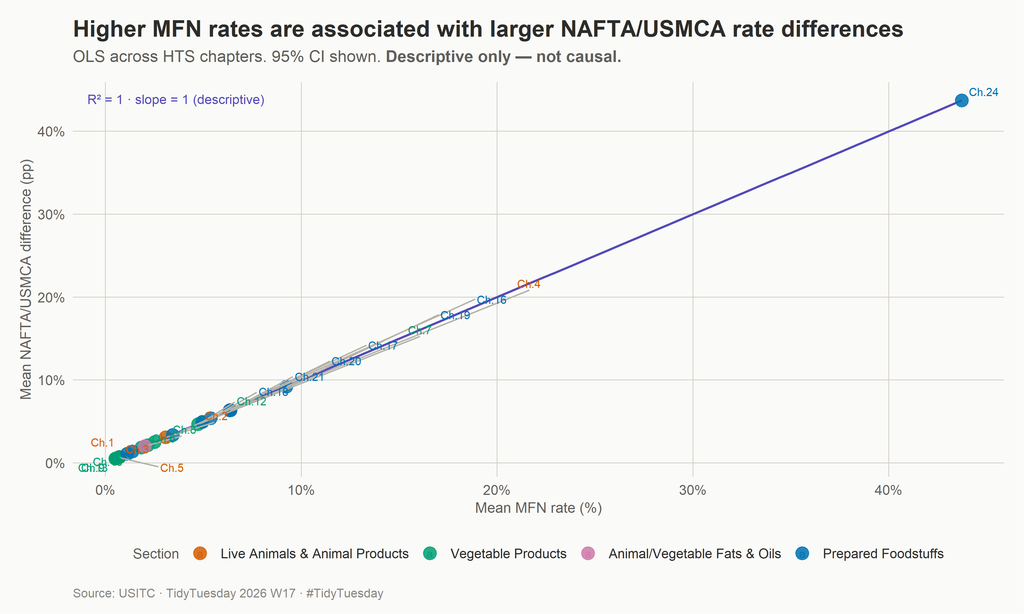

Figure 2: Descriptive OLS: chapters with higher MFN rates tend to have larger NAFTA/USMCA differences. Not causal.

```r
reg_data <- annual_panel |>
  filter(agree_group %in% c("MFN","NAFTA/USMCA")) |>
  group_by(hts_chapter, section, agree_group) |>
  summarise(avg = mean(ad_val_pct, na.rm = TRUE), .groups = "drop") |>
  pivot_wider(names_from = agree_group, values_from = avg) |>
  janitor::clean_names() |>
  filter(!is.na(mfn), !is.na(nafta_usmca)) |>
  mutate(saving = mfn - nafta_usmca)

model <- lm(saving ~ mfn, data = reg_data)
r2    <- glance(model)$r.squared
slope <- tidy(model)$estimate[2]

ggplot(reg_data, aes(x = mfn, y = saving, colour = section)) +
  geom_smooth(method = "lm", se = TRUE, colour = "#534AB7",
              fill = "#EEEDFE", linewidth = 0.8, alpha = 0.25) +
  geom_point(size = 4, alpha = 0.85) +
  geom_text_repel(aes(label = glue("Ch.{hts_chapter}")),
                  size = 2.8, max.overlaps = 20,
                  segment.colour = "#B4B2A9") +
  scale_colour_manual(values = pal_section, name = "Section") +
  scale_x_continuous(labels = label_number(suffix = "%")) +
  scale_y_continuous(labels = label_number(suffix = "%")) +
  annotate("richtext", x = -Inf, y = Inf, hjust = -0.05, vjust = 1.3,
           label = glue("R² = {round(r2,3)} · slope = {round(slope,2)} (descriptive)"),
           fill = NA, label.colour = NA, size = 3.2, colour = "#534AB7") +
  labs(
    title    = "Higher MFN rates are associated with larger NAFTA/USMCA rate differences",
    subtitle = "OLS across HTS chapters. 95% CI shown. **Descriptive only — not causal.**",
    x = "Mean MFN rate (%)", y = "Mean NAFTA/USMCA difference (pp)",
    caption  = "Source: USITC · TidyTuesday 2026 W17 · #TidyTuesday"
  )
```

**Show / hide code**

```r
bind_rows(
  tidy(model)   |> mutate(type = "Coefficients"),
  glance(model) |>
    select(r.squared, adj.r.squared, p.value, nobs) |>
    pivot_longer(everything(), names_to = "term", values_to = "estimate") |>
    mutate(type = "Model fit", std.error = NA_real_,
           statistic = NA_real_, p.value = NA_real_)
) |>
  gt() |>
  tab_header(title    = md("**OLS: NAFTA/USMCA saving ~ MFN rate (descriptive)**"),
             subtitle = md("*Unit: HTS chapter. No causal interpretation.*")) |>
  fmt_number(columns = where(is.numeric), decimals = 3) |>
  tab_row_group(label = "Coefficients", rows = type == "Coefficients") |>
  tab_row_group(label = "Model fit",    rows = type == "Model fit") |>
  cols_hide(type) |>
  tab_options(table.font.size = px(13))
```

Table 7: OLS regression output (descriptive)

**OLS: NAFTA/USMCA saving ~ MFN rate (descriptive)**

*Unit: HTS chapter. No causal interpretation.*

| term | estimate | std.error | statistic | p.value |
| --- | --- | --- | --- | --- |
| Model fit |  |  |  |  |
| r.squared | 1.000 | NA | NA | NA |
| adj.r.squared | 1.000 | NA | NA | NA |
| p.value | 0.000 | NA | NA | NA |
| nobs | 24.000 | NA | NA | NA |
| Coefficients |  |  |  |  |
| (Intercept) | −0.011 | 0.005 | −2.112 | 0.046 |
| mfn | 1.000 | 0.001 | 1,942.442 | 0.000 |

### 4.5 Lorenz / Gini: tariff rate inequality

**Show / hide code**

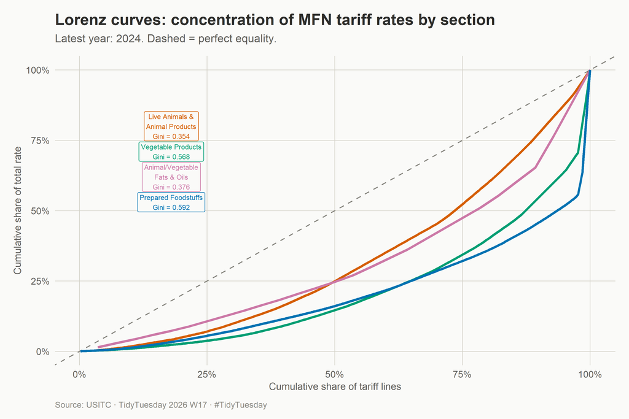

Figure 3: Lorenz curves by section. Convexity = concentration of high rates in few tariff lines.

```r
gini_fn <- function(x) {
  x <- sort(x[x > 0 & !is.na(x)])
  n <- length(x)
  if (n < 2) return(NA_real_)
  (2 * sum(seq_len(n) * x) / (n * sum(x))) - (n + 1) / n
}

lorenz_df <- mfn_panel |>
  filter(year == max(year)) |>
  group_by(section) |>
  filter(mfn_rate > 0) |>
  arrange(mfn_rate) |>
  mutate(
    cum_pop  = row_number() / n(),
    cum_rate = cumsum(mfn_rate) / sum(mfn_rate)
  ) |> ungroup()

gini_vals <- mfn_panel |>
  filter(year == max(year)) |>
  group_by(section) |>
  summarise(gini = gini_fn(mfn_rate), .groups = "drop") |>
  mutate(label = sprintf("Gini = %.3f", gini),
         x = 0.18, y = 0.80 - (as.integer(section) - 1) * 0.09)

ggplot(lorenz_df, aes(x = cum_pop, y = cum_rate, colour = section)) +
  geom_abline(slope = 1, intercept = 0, linetype = "dashed",
              colour = "#888780", linewidth = 0.6) +
  geom_line(linewidth = 1.2) +
  geom_label(data = gini_vals,
             aes(x = x, y = y,
                 label = paste0(str_wrap(as.character(section), 20), "\n", label),
                 colour = section),
             size = 2.5, fill = "#FAFAF8", label.size = 0.3,
             show.legend = FALSE) +
  scale_colour_manual(values = pal_section, guide = "none") +
  scale_x_continuous(labels = label_percent()) +
  scale_y_continuous(labels = label_percent()) +
  labs(
    title    = "Lorenz curves: concentration of MFN tariff rates by section",
    subtitle = glue("Latest year: {max(mfn_panel$year)}. Dashed = perfect equality."),
    x = "Cumulative share of tariff lines",
    y = "Cumulative share of total rate",
    caption  = "Source: USITC · TidyTuesday 2026 W17 · #TidyTuesday"
  )
```

## 5 Visualisations

### 5.1 MFN rate trajectories

**Show / hide code**

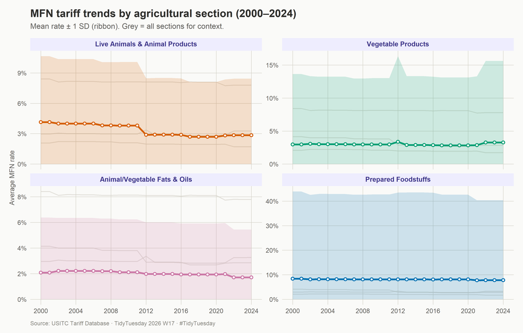

Figure 4: Mean MFN ad valorem rate by HTS section (2000–2024). Ribbon = ±1 SD. Grey = all sections.

```r
section_yr <- mfn_panel |>
  group_by(section, year) |>
  summarise(
    mean_rate  = mean(mfn_rate, na.rm = TRUE),
    sd_rate    = sd(mfn_rate, na.rm = TRUE),
    n_products = n_distinct(hts8),
    .groups = "drop"
  ) |>
  filter(n_products >= 5) |>
  mutate(lo = pmax(mean_rate - sd_rate, 0), hi = mean_rate + sd_rate)

bg_lines <- section_yr |> rename(bg_section = section)

ggplot() +
  geom_line(data = bg_lines,
            aes(x = year, y = mean_rate, group = bg_section),
            colour = "#D3D1C7", linewidth = 0.7, alpha = 0.6) +
  geom_ribbon(data = section_yr,
              aes(x = year, ymin = lo, ymax = hi, fill = section), alpha = 0.18) +
  geom_line(data = section_yr,
            aes(x = year, y = mean_rate, colour = section), linewidth = 1.3) +
  geom_point(data = section_yr,
             aes(x = year, y = mean_rate, colour = section),
             size = 1.6, shape = 21, fill = "white", stroke = 1.0) +
  scale_colour_manual(values = pal_section, guide = "none") +
  scale_fill_manual(values = pal_section, guide = "none") +
  scale_x_continuous(breaks = seq(2000, 2024, 4)) +
  scale_y_continuous(labels = label_number(suffix = "%"), limits = c(0, NA)) +
  facet_wrap(~section, ncol = 2, scales = "free_y") +
  labs(
    title    = "MFN tariff trends by agricultural section (2000–2024)",
    subtitle = "Mean rate ± 1 SD (ribbon). Grey = all sections for context.",
    x = NULL, y = "Average MFN rate",
    caption  = "Source: USITC Tariff Database · TidyTuesday 2026 W17 · #TidyTuesday"
  )
```

### 5.2 Year-over-year change heatmap

**Show / hide code**

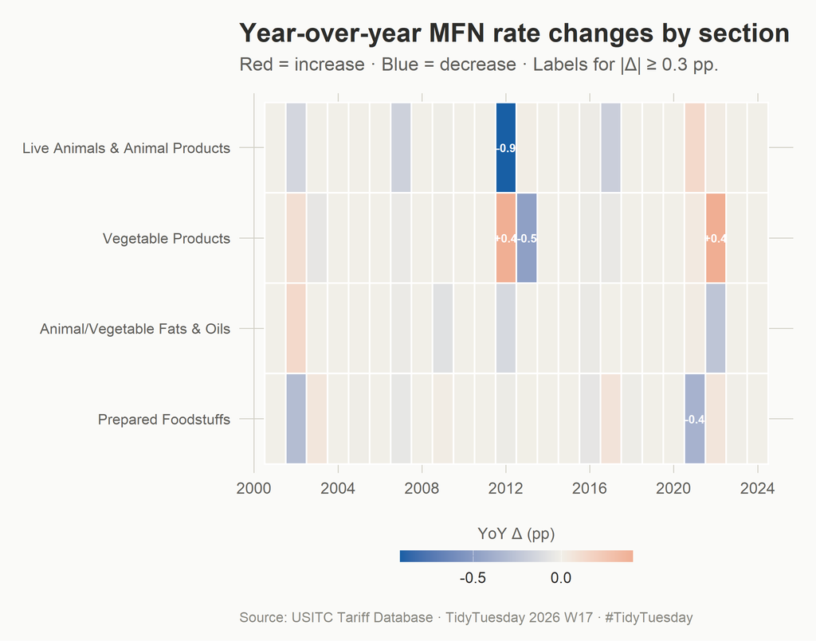

Figure 5: Year-over-year change in mean MFN rate per section. Red = increase, blue = decrease.

```r
mfn_panel |>
  group_by(section, year) |>
  summarise(mean_rate = mean(mfn_rate, na.rm = TRUE), .groups = "drop") |>
  arrange(section, year) |>
  group_by(section) |>
  mutate(yoy_change = mean_rate - lag(mean_rate)) |>
  ungroup() |>
  filter(!is.na(yoy_change)) |>
  ggplot(aes(x = year, y = fct_rev(section), fill = yoy_change)) +
  geom_tile(colour = "white", linewidth = 0.5) +
  geom_text(aes(label = ifelse(abs(yoy_change) >= 0.3,
                               sprintf("%+.1f", yoy_change), "")),
            size = 2.5, colour = "white", fontface = "bold") +
  scale_fill_gradient2(
    low = "#185FA5", mid = "#F1EFE8", high = "#D85A30", midpoint = 0,
    name = "YoY Δ (pp)",
    guide = guide_colourbar(barwidth = 10, barheight = 0.5,
                            title.position = "top", title.hjust = 0.5)
  ) +
  scale_x_continuous(breaks = seq(2000, 2024, 4)) +
  labs(
    title    = "Year-over-year MFN rate changes by section",
    subtitle = "Red = increase · Blue = decrease · Labels for |Δ| ≥ 0.3 pp.",
    x = NULL, y = NULL,
    caption  = "Source: USITC Tariff Database · TidyTuesday 2026 W17 · #TidyTuesday"
  ) +
  theme(panel.grid = element_blank(), axis.text.y = element_markdown(size = 9))
```

### 5.3 Agreement coverage heatmap

**Show / hide code**

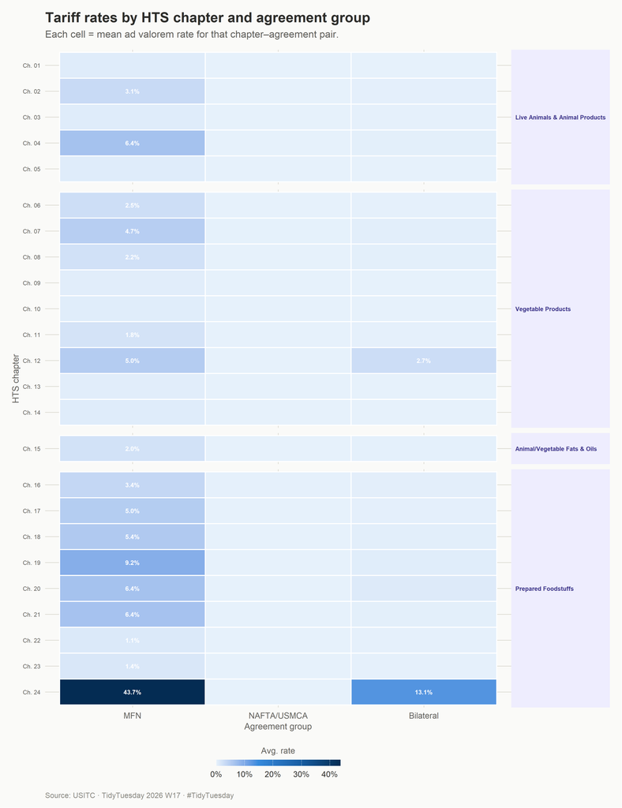

Figure 6: Average ad valorem rate by HTS chapter and agreement group. Darker = higher rates.

```r
annual_panel |>
  mutate(chapter_label = glue("Ch. {str_pad(hts_chapter, 2, 'left', '0')}")) |>
  group_by(section, hts_chapter, chapter_label, agree_group) |>
  summarise(avg_rate = mean(ad_val_pct, na.rm = TRUE), .groups = "drop") |>
  filter(agree_group %in% c("MFN","NAFTA/USMCA","Bilateral")) |>
  mutate(
    agree_group   = factor(agree_group, levels = c("MFN","NAFTA/USMCA","Bilateral")),
    chapter_label = fct_reorder(chapter_label, hts_chapter)
  ) |>
  ggplot(aes(x = agree_group, y = fct_rev(chapter_label), fill = avg_rate)) +
  geom_tile(colour = "white", linewidth = 0.6) +
  geom_text(aes(label = ifelse(avg_rate >= 1, sprintf("%.1f%%", avg_rate), "")),
            size = 2.5, colour = "white", fontface = "bold") +
  scale_fill_gradientn(
    colours  = c("#E6F1FB","#378ADD","#185FA5","#042C53"),
    na.value = "#F1EFE8", name = "Avg. rate",
    labels   = label_number(suffix = "%"),
    guide    = guide_colourbar(barwidth = 10, barheight = 0.5,
                               title.position = "top", title.hjust = 0.5)
  ) +
  facet_grid(section ~ ., scales = "free_y", space = "free_y") +
  labs(
    title    = "Tariff rates by HTS chapter and agreement group",
    subtitle = "Each cell = mean ad valorem rate for that chapter–agreement pair.",
    x = "Agreement group", y = "HTS chapter",
    caption  = "Source: USITC · TidyTuesday 2026 W17 · #TidyTuesday"
  ) +
  theme(panel.grid   = element_blank(),
        axis.text.y  = element_text(size = 7),
        strip.text.y = element_text(angle = 0, hjust = 0, size = 7))
```

### 5.4 MFN vs NAFTA/USMCA dumbbell

**Show / hide code**

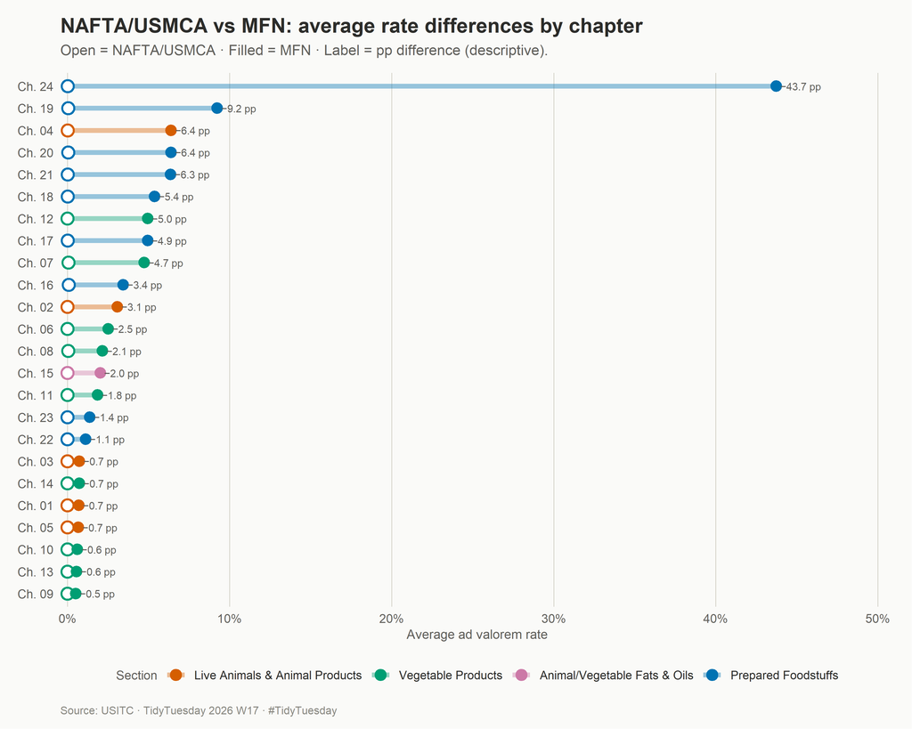

Figure 7: MFN (filled) vs NAFTA/USMCA (open) average rates per chapter. Segment = pp difference.

```r
dumbbell_data <- annual_panel |>
  filter(agree_group %in% c("MFN","NAFTA/USMCA")) |>
  group_by(hts_chapter, section, agree_group) |>
  summarise(avg_rate = mean(ad_val_pct, na.rm = TRUE), .groups = "drop") |>
  pivot_wider(names_from = agree_group, values_from = avg_rate) |>
  clean_names() |>
  filter(!is.na(mfn), !is.na(nafta_usmca)) |>
  mutate(
    saving        = mfn - nafta_usmca,
    chapter_label = glue("Ch. {str_pad(hts_chapter, 2, 'left', '0')}"),
    chapter_label = fct_reorder(chapter_label, saving)
  ) |>
  filter(saving > 0)

ggplot(dumbbell_data) +
  geom_segment(aes(x = nafta_usmca, xend = mfn,
                   y = chapter_label, yend = chapter_label, colour = section),
               linewidth = 1.8, alpha = 0.40) +
  geom_point(aes(x = nafta_usmca, y = chapter_label, colour = section),
             size = 3.8, shape = 21, fill = "white", stroke = 1.2) +
  geom_point(aes(x = mfn, y = chapter_label, colour = section), size = 3.8) +
  geom_text(aes(x = mfn + 0.25, y = chapter_label,
                label = sprintf("−%.1f pp", saving)),
            hjust = 0, size = 2.9, colour = "#5F5E5A") +
  scale_colour_manual(values = pal_section, name = "Section") +
  scale_x_continuous(labels = label_number(suffix = "%"),
                     expand = expansion(mult = c(0.01, 0.16))) +
  guides(colour = guide_legend(override.aes = list(size = 3))) +
  labs(
    title    = "NAFTA/USMCA vs MFN: average rate differences by chapter",
    subtitle = "Open = NAFTA/USMCA · Filled = MFN · Label = pp difference (descriptive).",
    x = "Average ad valorem rate", y = NULL,
    caption  = "Source: USITC · TidyTuesday 2026 W17 · #TidyTuesday"
  ) +
  theme(panel.grid.major.y = element_blank())
```

### 5.5 Tariff volatility — top 30 lines

**Show / hide code**

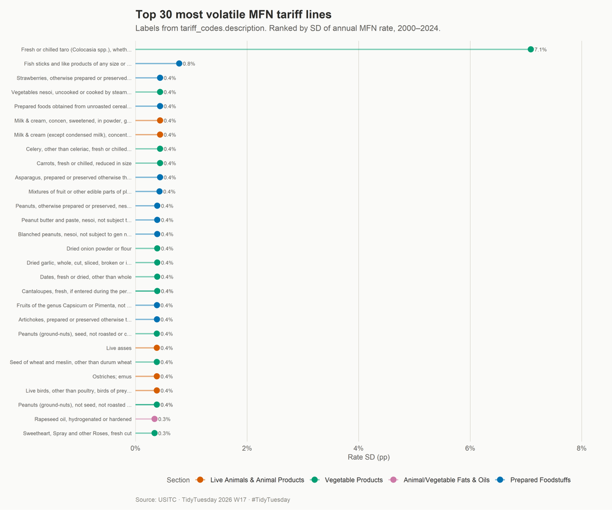

Figure 8: Top 30 MFN tariff lines by rate SD. Labels use product_desc from tariff_codes.csv.

```r
mfn_panel |>
  group_by(hts8, section, product_desc) |>
  filter(n() >= 5) |>
  summarise(rate_sd  = sd(mfn_rate, na.rm = TRUE),
            mean_mfn = mean(mfn_rate, na.rm = TRUE), .groups = "drop") |>
  filter(mean_mfn > 0) |>
  slice_max(rate_sd, n = 30) |>
  mutate(
    label = coalesce(str_trunc(product_desc, 48), as.character(hts8)),
    label = fct_reorder(label, rate_sd)
  ) |>
  ggplot(aes(x = rate_sd, y = label, colour = section)) +
  geom_segment(aes(x = 0, xend = rate_sd, y = label, yend = label),
               linewidth = 0.9, alpha = 0.50) +
  geom_point(size = 3.6) +
  geom_text(aes(label = sprintf("%.1f%%", rate_sd)),
            hjust = -0.3, size = 2.7, colour = "#5F5E5A") +
  scale_colour_manual(values = pal_section, name = "Section") +
  scale_x_continuous(labels = label_number(suffix = "%"),
                     expand = expansion(mult = c(0, 0.18))) +
  labs(
    title    = "Top 30 most volatile MFN tariff lines",
    subtitle = "Labels from tariff_codes.description. Ranked by SD of annual MFN rate, 2000–2024.",
    x = "Rate SD (pp)", y = NULL,
    caption  = "Source: USITC · TidyTuesday 2026 W17 · #TidyTuesday"
  ) +
  theme(panel.grid.major.y = element_blank(), axis.text.y = element_text(size = 7.5))
```

### 5.6 NAFTA → USMCA transition

**Show / hide code**

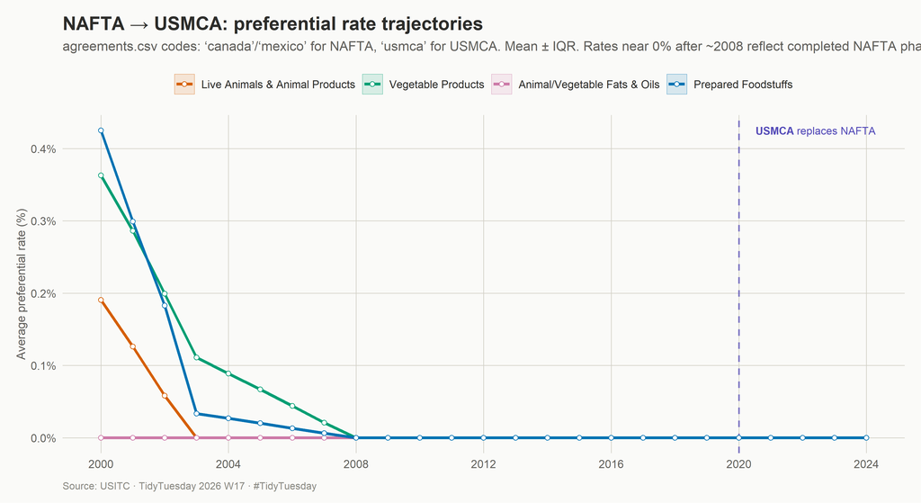

Figure 9: NAFTA/USMCA preferential rate trajectories. Dashed = USMCA effective date (2020).

```r
nafta_section <- annual_panel |>
  filter(agree_group == "NAFTA/USMCA") |>
  group_by(year, section) |>
  summarise(
    mean_rate = mean(ad_val_pct, na.rm = TRUE),
    lo        = quantile(ad_val_pct, 0.25, na.rm = TRUE),
    hi        = quantile(ad_val_pct, 0.75, na.rm = TRUE),
    .groups   = "drop"
  )

ggplot(nafta_section, aes(x = year, colour = section, fill = section)) +
  geom_vline(xintercept = 2020, linetype = "dashed",
             colour = "#534AB7", linewidth = 0.7, alpha = 0.7) +
  geom_ribbon(aes(ymin = lo, ymax = hi), alpha = 0.14, linewidth = 0) +
  geom_line(aes(y = mean_rate), linewidth = 1.2) +
  geom_point(aes(y = mean_rate), size = 1.7, shape = 21, fill = "white") +
  annotate("richtext", x = 2020.4, y = Inf, hjust = 0, vjust = 1.4,
           size = 3.2, label = "**USMCA** replaces NAFTA",
           fill = NA, label.colour = NA, colour = "#534AB7") +
  scale_colour_manual(values = pal_section, name = NULL) +
  scale_fill_manual(values = pal_section, name = NULL) +
  scale_x_continuous(breaks = seq(2000, 2024, 4)) +
  scale_y_continuous(labels = label_number(suffix = "%"), limits = c(0, NA)) +
  labs(
    title    = "NAFTA → USMCA: preferential rate trajectories",
    subtitle = "agreements.csv codes: 'canada'/'mexico' for NAFTA, 'usmca' for USMCA. Mean ± IQR.\nRates near 0% after ~2008 reflect completed NAFTA phase-out schedules.",
    x = NULL, y = "Average preferential rate (%)",
    caption  = "Source: USITC · TidyTuesday 2026 W17 · #TidyTuesday"
  ) +
  theme(legend.position = "top")
```

### 5.7 Biggest rate movers

**Show / hide code**

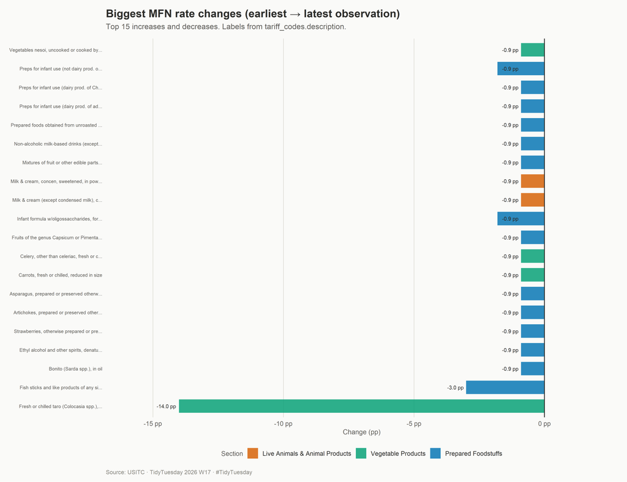

```r
big_movers <- mfn_panel |>
  group_by(hts8, section, product_desc) |>
  filter(n_distinct(year) >= 10) |>
  summarise(
    rate_start = mean(mfn_rate[year == min(year)], na.rm = TRUE),
    rate_end   = mean(mfn_rate[year == max(year)], na.rm = TRUE),
    change     = rate_end - rate_start, .groups = "drop"
  ) |>
  filter(!is.na(change)) |>
  mutate(direction = if_else(change > 0, "Increase", "Decrease")) |>
  group_by(direction) |>
  slice_max(abs(change), n = 15) |>
  ungroup() |>
  mutate(
    label = coalesce(str_trunc(product_desc, 42), as.character(hts8)),
    label = fct_reorder(label, change)
  )

ggplot(big_movers, aes(x = change, y = label, fill = section)) +
  geom_col(alpha = 0.82, width = 0.72) +
  geom_vline(xintercept = 0, colour = "#2C2C2A", linewidth = 0.65) +
  geom_text(aes(label = sprintf("%+.1f pp", change),
                hjust = if_else(change > 0, -0.15, 1.15)),
            size = 2.8, colour = "#2C2C2A") +
  scale_fill_manual(values = pal_section, name = "Section") +
  scale_x_continuous(labels = label_number(suffix = " pp", style_positive = "plus"),
                     expand = expansion(mult = 0.20)) +
  labs(
    title    = "Biggest MFN rate changes (earliest → latest observation)",
    subtitle = "Top 15 increases and decreases. Labels from tariff_codes.description.",
    x = "Change (pp)", y = NULL,
    caption  = "Source: USITC · TidyTuesday 2026 W17 · #TidyTuesday"
  ) +
  theme(panel.grid.major.y = element_blank(),
        axis.text.y        = element_markdown(size = 7.2))
```

### 5.8 Agreements vs MFN rate — bubble

**Show / hide code**

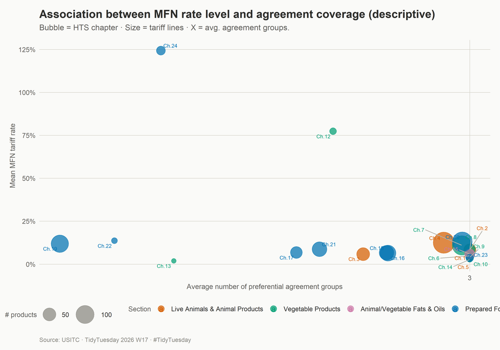

Figure 11: Association between MFN rate level and preferential agreement group coverage — descriptive only.

```r
bubble_chapter <- annual_panel |>
  group_by(hts8, hts_chapter, section) |>
  summarise(
    n_agreements = n_distinct(agree_group[agree_group != "MFN"]),
    mean_mfn     = mean(ad_val_pct[agree_group == "MFN"], na.rm = TRUE),
    .groups      = "drop"
  ) |>
  filter(!is.na(mean_mfn), mean_mfn > 0) |>
  group_by(hts_chapter, section) |>
  summarise(
    n_agreements = mean(n_agreements, na.rm = TRUE),
    mean_mfn     = mean(mean_mfn, na.rm = TRUE),
    n_products   = n(), .groups = "drop"
  ) |>
  mutate(chapter_label = glue("Ch.{hts_chapter}"))

ggplot(bubble_chapter,
       aes(x = n_agreements, y = mean_mfn,
           size = n_products, colour = section)) +
  geom_point(alpha = 0.72) +
  geom_text_repel(aes(label = chapter_label), size = 2.7, max.overlaps = 20,
                  segment.colour = "#B4B2A9", segment.linewidth = 0.4) +
  scale_size_area(max_size = 14, name = "# products") +
  scale_colour_manual(values = pal_section, name = "Section") +
  scale_x_continuous(breaks = 0:5, minor_breaks = NULL) +
  scale_y_continuous(labels = label_number(suffix = "%")) +
  guides(size   = guide_legend(override.aes = list(colour = "#888780")),
         colour = guide_legend(override.aes = list(size = 4))) +
  labs(
    title    = "Association between MFN rate level and agreement coverage (descriptive)",
    subtitle = "Bubble = HTS chapter · Size = tariff lines · X = avg. agreement groups.",
    x = "Average number of preferential agreement groups",
    y = "Mean MFN tariff rate",
    caption  = "Source: USITC · TidyTuesday 2026 W17 · #TidyTuesday"
  )
```

### 5.9 Tariff type composition

**Show / hide code**

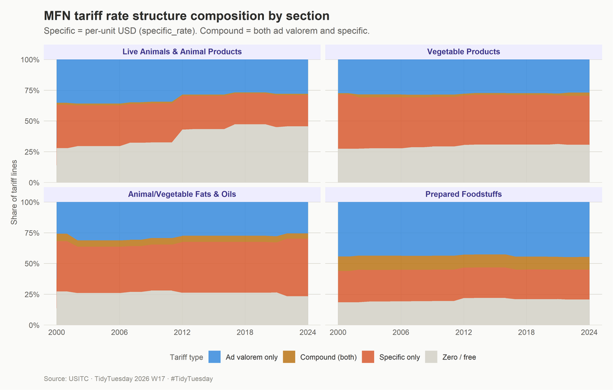

Figure 12: Share of MFN lines by rate structure. Specific = $/unit from specific_rate column.

```r
type_pal <- c("Ad valorem only" = "#378ADD", "Specific only" = "#D85A30",
              "Compound (both)" = "#BA7517", "Zero / free"   = "#D3D1C7")

annual_panel |>
  filter(agree_group == "MFN") |>
  mutate(
    rate_type = case_when(
      !is.na(specific_rate) & specific_rate > 0 &
        !is.na(ad_val_pct)   & ad_val_pct   > 0  ~ "Compound (both)",
      !is.na(specific_rate) & specific_rate > 0  ~ "Specific only",
      !is.na(ad_val_pct)   & ad_val_pct   > 0  ~ "Ad valorem only",
      TRUE                                       ~ "Zero / free"
    )
  ) |>
  count(year, section, rate_type) |>
  group_by(year, section) |>
  mutate(share = n / sum(n)) |>
  ungroup() |>
  ggplot(aes(x = year, y = share, fill = rate_type)) +
  geom_area(alpha = 0.85, position = "stack") +
  scale_fill_manual(values = type_pal, name = "Tariff type") +
  scale_x_continuous(breaks = seq(2000, 2024, 6)) +
  scale_y_continuous(labels = label_percent(), expand = c(0, 0)) +
  facet_wrap(~section, ncol = 2) +
  labs(
    title    = "MFN tariff rate structure composition by section",
    subtitle = "Specific = per-unit USD (specific_rate). Compound = both ad valorem and specific.",
    x = NULL, y = "Share of tariff lines",
    caption  = "Source: USITC · TidyTuesday 2026 W17 · #TidyTuesday"
  ) +
  theme(legend.position = "bottom")
```

### 5.10 Rate distribution ridgelines

**Show / hide code**

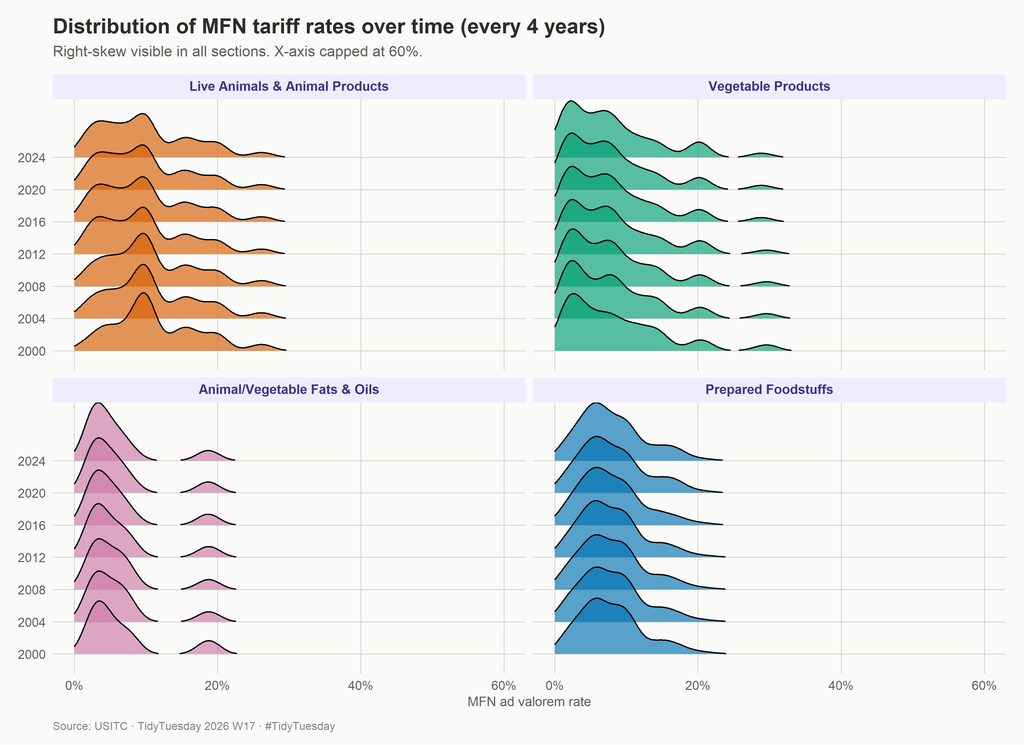

Figure 13: MFN ad valorem rate distributions every four years. X-axis capped at 60%.

```r
mfn_panel |>
  filter(year %in% seq(2000, 2024, 4), mfn_rate > 0, mfn_rate <= 100) |>
  mutate(year_f = factor(year)) |>
  ggplot(aes(x = mfn_rate, y = year_f, fill = section)) +
  geom_density_ridges(alpha = 0.65, scale = 1.8,
                      rel_min_height = 0.01, bandwidth = 1.5) +
  scale_fill_manual(values = pal_section, name = NULL) +
  scale_x_continuous(labels = label_number(suffix = "%"), limits = c(0, 60)) +
  facet_wrap(~section, ncol = 2) +
  labs(
    title    = "Distribution of MFN tariff rates over time (every 4 years)",
    subtitle = "Right-skew visible in all sections. X-axis capped at 60%.",
    x = "MFN ad valorem rate", y = NULL,
    caption  = "Source: USITC · TidyTuesday 2026 W17 · #TidyTuesday"
  ) +
  theme(legend.position = "none")
```

## 6 Statistical Tests

Statistical significance does not imply practical importance or causation. Tests below assess consistency with random variation only.

### 6.1 Kruskal-Wallis

**Show / hide code**

```r
kw <- kruskal.test(mfn_rate ~ section, data = mfn_panel)

tibble(
  Test      = "Kruskal-Wallis rank-sum",
  Statistic = round(kw$statistic, 2),
  df        = kw$parameter,
  `p-value` = formatC(kw$p.value, format = "e", digits = 3),
  Conclusion = if_else(kw$p.value < 0.05,
                       "Rate distributions differ across sections (p < 0.05)",
                       "No significant difference detected")
) |>
  gt() |>
  tab_header(title    = md("**Kruskal-Wallis test**"),
             subtitle = md("*H₀: all sections share the same rate distribution*")) |>
  tab_style(style = cell_text(weight = "bold"),
            locations = cells_column_labels()) |>
  tab_options(table.font.size = px(13))
```

Table 8: Kruskal-Wallis test: do MFN rate distributions differ across HTS sections?

**Kruskal-Wallis test**

*H₀: all sections share the same rate distribution*

| Test | Statistic | df | p-value | Conclusion |
| --- | --- | --- | --- | --- |
| Kruskal-Wallis rank-sum | 2773.24 | 3 | 0.000e+00 | Rate distributions differ across sections (p < 0.05) |

### 6.2 Dunn post-hoc

**Show / hide code**

```r
dunn_res <- dunn.test(
  mfn_panel$mfn_rate, mfn_panel$section,
  method = "bonferroni", alpha = 0.05, kw = FALSE, label = TRUE
)

tibble(
  Comparison   = dunn_res$comparisons,
  Z            = round(dunn_res$Z, 3),
  `p-adjusted` = round(dunn_res$P.adjusted, 4),
  Significant  = if_else(dunn_res$P.adjusted < 0.05, "Yes ✓", "No")
) |>
  gt() |>
  tab_header(title    = md("**Dunn post-hoc (Bonferroni)**"),
             subtitle = md("*Pairwise section comparisons*")) |>
  tab_style(style = cell_fill(color = "#EAF3DE"),
            locations = cells_body(rows = Significant == "Yes ✓")) |>
  tab_style(style = cell_text(weight = "bold"),
            locations = cells_column_labels()) |>
  tab_options(table.font.size = px(13))
```

Table 9: Dunn pairwise comparisons (Bonferroni correction)

**Dunn post-hoc (Bonferroni)**

*Pairwise section comparisons*

| Comparison | Z | p-adjusted | Significant |
| --- | --- | --- | --- |
| Animal/Vegetable Fats & Oils - Live Animals & Animal Products | -3.871 | 3e-04 | Yes ✓ |
| Animal/Vegetable Fats & Oils - Prepared Foodstuffs | -21.280 | 0e+00 | Yes ✓ |
| Live Animals & Animal Products - Prepared Foodstuffs | -39.228 | 0e+00 | Yes ✓ |
| Animal/Vegetable Fats & Oils - Vegetable Products | 0.407 | 1e+00 | No |
| Live Animals & Animal Products - Vegetable Products | 9.210 | 0e+00 | Yes ✓ |
| Prepared Foodstuffs - Vegetable Products | 47.961 | 0e+00 | Yes ✓ |

### 6.3 Mann-Kendall trend test

**Show / hide code**

```r
mfn_panel |>
  group_by(section, year) |>
  summarise(mean_rate = mean(mfn_rate, na.rm = TRUE), .groups = "drop") |>
  group_by(section) |>
  summarise(
    tau     = MannKendall(mean_rate)$tau[[1]],
    p_value = MannKendall(mean_rate)$sl[[1]],
    trend   = case_when(
      p_value >= 0.05           ~ "No monotonic trend detected",
      tau < 0 & p_value < 0.05 ~ "Significant decrease ↓",
      tau > 0 & p_value < 0.05 ~ "Significant increase ↑"
    ),
    .groups = "drop"
  ) |>
  gt() |>
  tab_header(title    = md("**Mann-Kendall trend test (2000–2024)**"),
             subtitle = md("*H₀: no monotonic trend in annual mean MFN rate*")) |>
  cols_label(section = "Section", tau = "Kendall τ",
             p_value = "p-value", trend = "Conclusion") |>
  fmt_number(columns = c(tau, p_value), decimals = 4) |>
  tab_style(style = cell_fill(color = "#E6F1FB"),
            locations = cells_body(rows = str_detect(trend, "decrease"))) |>
  tab_style(style = cell_fill(color = "#FAEEDA"),
            locations = cells_body(rows = str_detect(trend, "increase"))) |>
  tab_style(style = cell_text(weight = "bold"),
            locations = cells_column_labels()) |>
  tab_options(table.font.size = px(13))
```

Table 10: Mann-Kendall monotonic trend test by section (2000–2024)

**Mann-Kendall trend test (2000–2024)**

*H₀: no monotonic trend in annual mean MFN rate*

| Section | Kendall τ | p-value | Conclusion |
| --- | --- | --- | --- |
| Live Animals & Animal Products | −0.8002 | 0.0000 | Significant decrease ↓ |
| Vegetable Products | −0.2662 | 0.0737 | No monotonic trend detected |
| Animal/Vegetable Fats & Oils | −0.7646 | 0.0000 | Significant decrease ↓ |
| Prepared Foodstuffs | −0.7709 | 0.0000 | Significant decrease ↓ |

## 7 Interactive Exploration

### 7.1 Linked chapter explorer

**Show / hide code**

```r
shared_chapter <- mfn_panel |>
  group_by(hts_chapter, section) |>
  summarise(
    Products  = n_distinct(hts8),
    Mean_rate = round(mean(mfn_rate, na.rm = TRUE), 2),
    Median    = round(median(mfn_rate, na.rm = TRUE), 2),
    SD        = round(sd(mfn_rate, na.rm = TRUE), 2),
    Max       = round(max(mfn_rate, na.rm = TRUE), 2),
    .groups   = "drop"
  ) |>
  rename(Chapter = hts_chapter, Section = section) |>
  SharedData$new(key = ~Chapter)

filter_select("sec_filter", "Filter by section:", shared_chapter, ~Section)
```

Filter by section:

**Show / hide code**

```r
DT::datatable(
  shared_chapter, rownames = FALSE,
  extensions = "Buttons",
  options = list(dom = "Bfrtip", buttons = c("copy","csv"),
                 pageLength = 12, scrollX = TRUE)
) |>
  DT::formatStyle(
    "Mean_rate",
    background         = DT::styleColorBar(c(0, 30), "#378ADD"),
    backgroundSize     = "100% 90%",
    backgroundRepeat   = "no-repeat",
    backgroundPosition = "center"
  )
```

Table 11: MFN rate statistics by HTS chapter — select rows to highlight in scatter below

| Chapter | Section | Products | Mean_rate | Median | SD | Max |
| --- | --- | --- | --- | --- | --- | --- |
| 1 | Live Animals &amp; Animal Products | 59 | 0.69 | 0 | 1.64 | 6.8 |
| 2 | Live Animals &amp; Animal Products | 125 | 3.08 | 0 | 6.35 | 26.4 |
| 3 | Live Animals &amp; Animal Products | 405 | 0.73 | 0 | 2.26 | 15 |
| 4 | Live Animals &amp; Animal Products | 271 | 6.39 | 4.2 | 7.14 | 25 |
| 5 | Live Animals &amp; Animal Products | 23 | 0.67 | 0 | 1.33 | 5.1 |
| 6 | Vegetable Products | 40 | 2.52 | 1.4 | 2.69 | 7 |
| 7 | Vegetable Products | 234 | 4.74 | 0 | 6.76 | 29.8 |
| 8 | Vegetable Products | 164 | 2.16 | 0 | 5.43 | 29.8 |
| 9 | Vegetable Products | 81 | 0.51 | 0 | 1.46 | 6.4 |
| 10 | Vegetable Products | 40 | 0.6 | 0 | 2.07 | 11.2 |

[output cut: 14 more lines]

**Show / hide code**

```r
plot_ly(shared_chapter,
        x = ~Mean_rate, y = ~SD, size = ~Products, color = ~Section,
        colors = unname(pal_section), type = "scatter", mode = "markers",
        marker = list(opacity = 0.75, sizemode = "diameter"),
        hovertemplate = "<b>Ch %{customdata}</b><br>Mean: %{x:.1f}%<br>SD: %{y:.1f}%<extra></extra>",
        customdata = ~Chapter
) |>
  layout(
    title  = list(text = "Chapter rate level vs volatility (linked to table)"),
    xaxis  = list(title = "Mean MFN rate (%)", gridcolor = "#D3D1C7"),
    yaxis  = list(title = "Rate SD (pp)",       gridcolor = "#D3D1C7"),
    legend = list(orientation = "h", y = -0.2),
    paper_bgcolor = "#FAFAF8", plot_bgcolor = "#FAFAF8"
  ) |>
  highlight(on = "plotly_selected", off = "plotly_deselect",
            color = "#D85A30", persistent = TRUE)
```

[interactive chart not shown]

Figure 14: Linked scatter — select table rows to highlight chapters.

### 7.2 Interactive trajectories with IQR

**Show / hide code**

```r
section_yr_plotly <- mfn_panel |>
  group_by(section, year) |>
  summarise(
    mean_rate = mean(mfn_rate, na.rm = TRUE),
    lo        = quantile(mfn_rate, 0.25, na.rm = TRUE),
    hi        = quantile(mfn_rate, 0.75, na.rm = TRUE),
    .groups   = "drop"
  )

p <- plot_ly()
for (sec in levels(section_yr_plotly$section)) {
  d   <- filter(section_yr_plotly, section == sec)
  col <- pal_section[sec]
  p   <- add_ribbons(p, data = d, x = ~year, ymin = ~lo, ymax = ~hi,
                     fillcolor = paste0(col, "22"), line = list(width = 0),
                     name = paste0(sec, " IQR"), legendgroup = sec,
                     showlegend = FALSE, hoverinfo = "skip")
  p   <- add_lines(p, data = d, x = ~year, y = ~mean_rate,
                   line = list(color = col, width = 2.5),
                   name = sec, legendgroup = sec,
                   hovertemplate = paste0("<b>", sec, "</b><br>Year: %{x}<br>",
                                          "Mean: %{y:.2f}%<extra></extra>"))
}
p |> layout(
  title     = list(text = "MFN rate trajectories with IQR bands"),
  xaxis     = list(title = "", tickvals = seq(2000, 2024, 4), gridcolor = "#D3D1C7"),
  yaxis     = list(title = "Average MFN rate (%)", rangemode = "tozero",
                   gridcolor = "#D3D1C7"),
  legend    = list(orientation = "h", y = -0.2),
  hovermode = "x unified",
  paper_bgcolor = "#FAFAF8", plot_bgcolor = "#FAFAF8"
)
```

[interactive chart not shown]

Figure 15: Interactive MFN trajectories with IQR bands — unified hover tooltip.

## 8 Composite Dashboard

**Show / hide code**

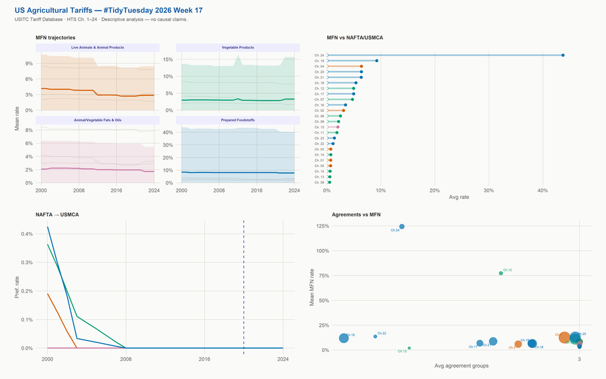

Figure 16: Four-panel summary dashboard — #TidyTuesday 2026 Week 17.

```r
p1 <- ggplot() +
  geom_line(data = bg_lines,
            aes(x = year, y = mean_rate, group = bg_section),
            colour = "#D3D1C7", linewidth = 0.5, alpha = 0.6) +
  geom_ribbon(data = section_yr,
              aes(x = year, ymin = lo, ymax = hi, fill = section), alpha = 0.15) +
  geom_line(data = section_yr,
            aes(x = year, y = mean_rate, colour = section), linewidth = 1.0) +
  scale_colour_manual(values = pal_section, guide = "none") +
  scale_fill_manual(values = pal_section, guide = "none") +
  scale_x_continuous(breaks = seq(2000, 2024, 8)) +
  scale_y_continuous(labels = label_number(suffix = "%")) +
  facet_wrap(~section, ncol = 2, scales = "free_y") +
  labs(title = "MFN trajectories", x = NULL, y = "Mean rate") +
  theme(plot.title = element_markdown(size = 9.5, face = "bold"),
        strip.text = element_markdown(size = 6.5))

p3 <- ggplot(dumbbell_data) +
  geom_segment(aes(x = nafta_usmca, xend = mfn,
                   y = chapter_label, yend = chapter_label, colour = section),
               linewidth = 1.4, alpha = 0.40) +
  geom_point(aes(x = nafta_usmca, y = chapter_label, colour = section),
             size = 2.2, shape = 21, fill = "white") +
  geom_point(aes(x = mfn, y = chapter_label, colour = section), size = 2.2) +
  scale_colour_manual(values = pal_section, guide = "none") +
  scale_x_continuous(labels = label_number(suffix = "%"),
                     expand = expansion(mult = c(0, 0.12))) +
  labs(title = "MFN vs NAFTA/USMCA", x = "Avg rate", y = NULL) +
  theme(plot.title = element_markdown(size = 9.5, face = "bold"),
        axis.text.y = element_text(size = 6),
        panel.grid.major.y = element_blank())

p5 <- ggplot(nafta_section, aes(x = year, colour = section, fill = section)) +
  geom_vline(xintercept = 2020, linetype = "dashed",
             colour = "#534AB7", linewidth = 0.6) +
  geom_ribbon(aes(ymin = lo, ymax = hi), alpha = 0.13, linewidth = 0) +
  geom_line(aes(y = mean_rate), linewidth = 1.0) +
  scale_colour_manual(values = pal_section, name = NULL) +
  scale_fill_manual(values = pal_section, name = NULL) +
  scale_x_continuous(breaks = seq(2000, 2024, 8)) +
  scale_y_continuous(labels = label_number(suffix = "%")) +
  labs(title = "NAFTA → USMCA", x = NULL, y = "Pref. rate") +
  theme(plot.title = element_markdown(size = 9.5, face = "bold"),
        legend.position = "none")

p7 <- ggplot(bubble_chapter,
             aes(x = n_agreements, y = mean_mfn,
                 size = n_products, colour = section)) +
  geom_point(alpha = 0.7) +
  geom_text_repel(aes(label = chapter_label), size = 2.1, max.overlaps = 15,
                  segment.colour = "#B4B2A9", segment.linewidth = 0.3) +
  scale_size_area(max_size = 10, guide = "none") +
  scale_colour_manual(values = pal_section, guide = "none") +
  scale_x_continuous(breaks = 0:4) +
  scale_y_continuous(labels = label_number(suffix = "%")) +
  labs(title = "Agreements vs MFN", x = "Avg agreement groups", y = "Mean MFN rate") +
  theme(plot.title = element_markdown(size = 9.5, face = "bold"))

(p1 | p3) / (p5 | p7) +
  plot_annotation(
    title    = "US Agricultural Tariffs — #TidyTuesday 2026 Week 17",
    subtitle = "USITC Tariff Database · HTS Ch. 1–24 · Descriptive analysis — no causal claims.",
    theme    = theme(
      plot.title    = element_markdown(size = 14, face = "bold", colour = "#185FA5"),
      plot.subtitle = element_markdown(size = 9,  colour = "#5F5E5A")
    )
  )
```